# Correlations Between Complexity Measures

Chris Bentz

January 12, 2021

# Load Libraries

If the libraries are not installed yet, you need to install them using, for example, the command: install.packages(“ggplot2”).

```r
library(readr)
library(ggplot2)
library(gridExtra)
library(GGally)
library(ggrepel)
library(psych)
library(corrplot)
```

# Load the Data

The participants’ results are loaded as csv files directly from the github repository into separate data frames. We only use the name of the first author (lower case) to name the data frame.

```r
#Track A (Parallel Bible Corpus, PBC)
gutierrez.results <- read_csv("https://raw.githubusercontent.com/IWMLC/language-complexity-metrics/master/PBCtrack/Gutierrez/Gutierrez.csv")
# remove the parentheses in column names
colnames(gutierrez.results) <- sub("\\(", "", colnames(gutierrez.results))
colnames(gutierrez.results) <- sub("\\)", "", colnames(gutierrez.results))
# replace "+" by "."
colnames(gutierrez.results) <- gsub("\\+", ".", colnames(gutierrez.results))
oh.results <- read_csv("https://raw.githubusercontent.com/IWMLC/language-complexity-metrics/master/PBCtrack/Oh/oh.csv")

#TRACK B (Universal Dependencies, UD)
brunato.results  <- read_csv("https://raw.githubusercontent.com/IWMLC/language-complexity-metrics/master/UDtrack/Brunato_venturi/Brunato-Venturi.csv")
coltekin.results  <- read_csv("https://raw.githubusercontent.com/IWMLC/language-complexity-metrics/master/UDtrack/Coltekin_rama/coltekin.csv")
semenuks.results  <- read_csv("https://raw.githubusercontent.com/IWMLC/language-complexity-metrics/master/UDtrack/Semenuks/Semenuks.csv")
sinnemaki.results  <- read_csv("https://raw.githubusercontent.com/IWMLC/language-complexity-metrics/master/UDtrack/Sinnemaki/Sinnemaki.csv")
sozinova.results  <- read_csv("https://raw.githubusercontent.com/IWMLC/language-complexity-metrics/master/UDtrack/Sozinova_etal/sozinova_etal.csv")
```

Sanity check, look at the number of rows and columns of the data frames.

```r
#Track A (should be 49 rows)
track.a.rows <- c(nrow(gutierrez.results), nrow(oh.results))
print(track.a.rows) # this corresponds to the number of languages
```

```
## [1] 49 49
```

```r
track.a.cols <- c(ncol(gutierrez.results), ncol(oh.results))
print(track.a.cols) # this is the number of measures per team
```

```
## [1] 14  5
```

```r
#Track B (should be 63 rows)
track.b.rows <- c(nrow(brunato.results), nrow(coltekin.results), nrow(semenuks.results), nrow(sinnemaki.results), nrow(sozinova.results))
print(track.b.rows) # this corresponds to the number of languages
```

```
## [1] 63 63 63 63 63
```

```r
track.b.cols <- c(ncol(brunato.results), ncol(coltekin.results), ncol(semenuks.results), ncol(sinnemaki.results), ncol(sozinova.results))
print(track.b.cols) # this is the number of measures per team
```

```
## [1] 13  8  4  8  4
```

# Preprocessing

Put data into a single data frame.

```r
track.a <- cbind(gutierrez.results, oh.results[, 3:ncol(oh.results)])
track.b <- cbind(brunato.results, coltekin.results[, 3:ncol(coltekin.results)],
                 semenuks.results[, 3:ncol(semenuks.results)],
                 sinnemaki.results[, 3:ncol(sinnemaki.results)],
                 sozinova.results[, 3:ncol(sozinova.results)])
```

Remove certain measures.

```r
# remove measures in TRACK A which are redundant (since the only difference is whether the parallel corpora
# are fully paralellized or not)
track.a <- track.a[ , -which(names(track.a) %in% c("GM_H1gram", "GM_H3gram", "GM_TTR",
                                                   "GM_TTR.H1", "GM_TTR.H3", "GM_TTR.H1.H3"))]
# remove measures in TRACK B with many NAs
track.b <- track.b[ , -which(names(track.b) %in% c("SI_double_dl", "SI_head_dl", "SI_zero_dl"))]
```

Invert the values (by substracting them from 1) for the measure “CR_inflection_accurracy” in Track B. Note that higher values in the original measure mean *lower* rather than higher complexity.

```r
track.b$CR_inflection_accuracy <- 1-track.b$CR_inflection_accuracy
```

Check the first 6 rows of the data.

```r
#head(track.a)
#head(track.b)
```

Remove the first two columns of data frames (useful for plotting).

```r
track.a.short <- track.a[, 3:ncol(track.a)]
track.b.short <- track.b[, 3:ncol(track.b)]
```

# Scatterplots by Track

## TRACK A

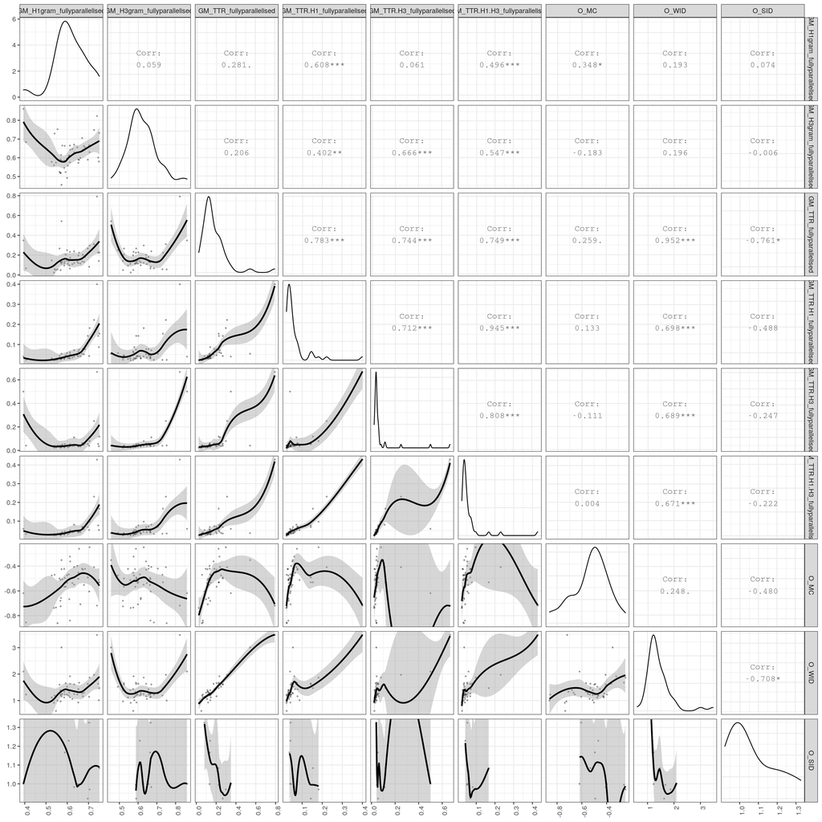

```r
track.a.scatterplot <- ggpairs(track.a.short,
                        lower = list(continuous = wrap("smooth_loess", alpha = 0.3,
                                                       lwd = 0.5, size = 2))) +
                        #upper = list(continuous = wrap('cor', method = "spearman"))) +
                        theme_bw() +
                        theme(axis.text.x = element_text(angle = 90, hjust = 1))
print(track.a.scatterplot)
```

Safe plot to file.

```r
ggsave("~/Github/ComplexityMetaAnalyses/Figures/Corrs/TrackA/track_a_scatterplot.pdf", track.a.scatterplot,
       dpi = 300, scale = 1, width = 15, height = 15, device = cairo_pdf)
```

## TRACK B

Same for the Track B data. Not all measures are included here (there would be 24). To include them all, the “columns” argument in the code below might be removed.

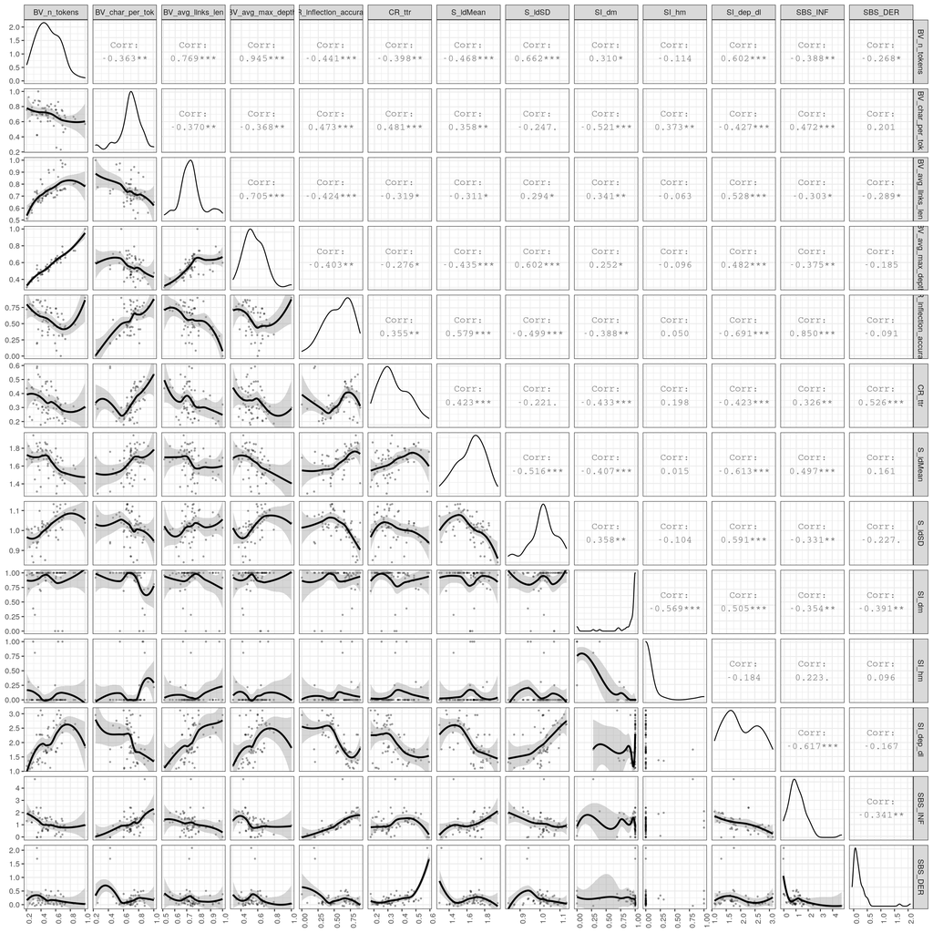

```r
track.b.scatterplot <- ggpairs(track.b.short, progress = TRUE,
                        lower = list(continuous = wrap("smooth_loess", alpha = 0.3,
                                                       lwd = 0.5, size = 2)),
                        upper = list(continuous = wrap('cor', method = "spearman")),
                        columns = c("BV_n_tokens", "BV_char_per_tok", "BV_avg_links_len",
                              "BV_avg_max_depth", "CR_inflection_accuracy", "CR_ttr",
                              "S_idMean", "S_idSD", "SI_dm", "SI_hm", "SI_dep_dl",
                              "SBS_INF", "SBS_DER")) +
                        theme_bw() +
                        theme(axis.text.x = element_text(angle = 90, hjust = 1))
print(track.b.scatterplot)
```

Safe plot to file.

```r
ggsave("~/Github/ComplexityMetaAnalyses/Figures/Corrs/TrackB/track_b_scatterplot.pdf", track.b.scatterplot,
       dpi = 300, scale = 1, width = 15, height = 15, device = cairo_pdf)
```

# Significant Correlations after Correction for Multiple testing

Not all of the correlations displayed above are going to be significant after correcting for multiple testing. We therefore use the corr.test() function here, since it enables us to choose a correction method, i.e. Holm-Bonferroni. The Bonferroni method would be more conservative, however, it is pointed out in (MacDonald 2014, p. 254-260) that it is appropriate only when tests are independent of one another. Since we here run pairwise tests by complexity measures, our tests are not independent (the same measure is tested against others multiple times). We therefore apply the Holm-Bonferroni method (see also the descriptions in the vignette invoked by the command “?p.adjust()”). Note that NAs are here deleted in pairs of columns, rather than across a whole row.

## TRACK A

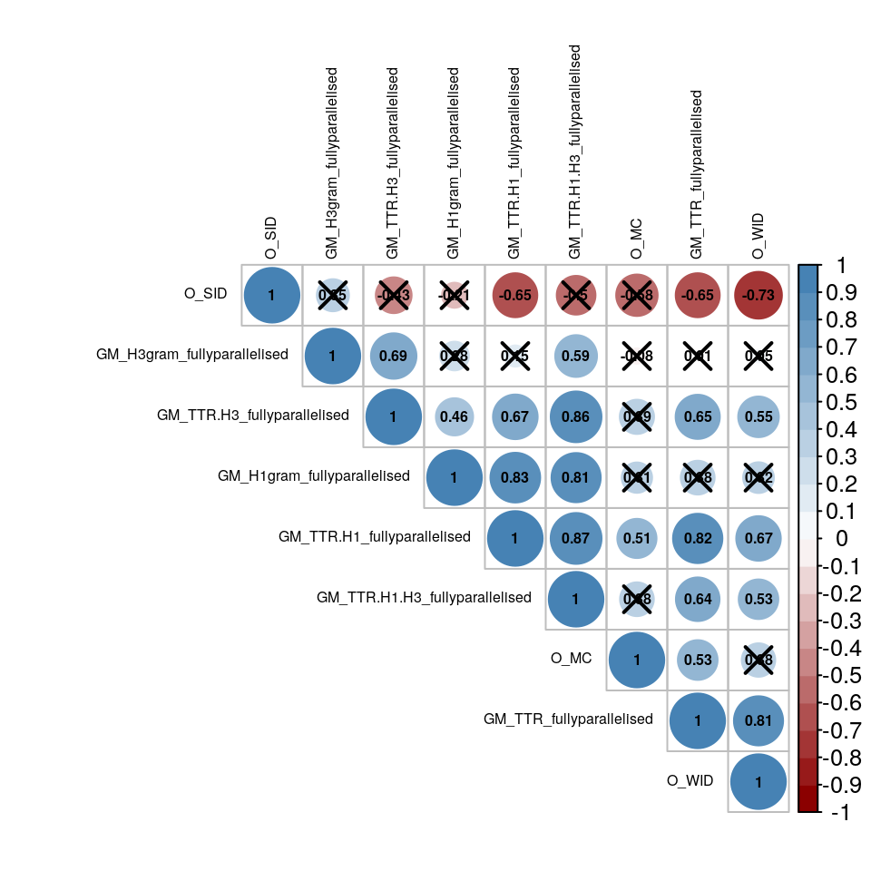

```r
cor.results <- corr.test(track.a.short, method = "spearman",
                         use = "pairwise.complete.obs", adjust = "holm")
# define color range
col <- colorRampPalette(c("darkred", "white", "steelblue"))(20)
# give correlation plot
corrplot(cor.results$r, type = "upper", order = "hclust", col = col,
         tl.col = "black", tl.cex = 0.5,
         addCoef.col = "black", number.cex = 0.5,
         p.mat = cor.results$p,
         pch.cex = 2,
         #pch.col = "gray",
         sig.level = 0.05, insig = "pch")
```